# 반도체 기술 심층분석 — 선단 공정 로드맵 (3nm→2nm→A14, GAA vs FinFET)

Alpha Hunter Tech Deep Dive #4 | 관련 종목: ONTO Innovation, 프로텍, ISC, HPSP, ASML

Author

Alpha Hunter × Chimera AI

Published

May 27, 2026

# 개요: 트랜지스터 혁명의 전환점

**핵심 메시지**

**GAA(Gate-All-Around) 나노시트**는 반도체 역사상 가장 중요한 트랜지스터 구조 전환이다. 2011년 도입된 FinFET은 3nm까지 스케일링을 이끌었지만, 채널 바닥의 누설전류 문제로 한계에 도달했다. GAA는 게이트가 채널을 **사방(4면)**에서 감싸 누설전류를 70% 이상 줄이며, TSMC N2·삼성 SF2·Intel 18A 모두 이 구조를 채택해 2nm 시대를 열었다. 이후 CFET(상보형 FET)·BSPDN(후면 전력 전달)까지, 선단 공정 로드맵은 2030년대까지 뚜렷한 진화 경로를 갖고 있다.

반도체 미세공정은 무어의 법칙을 연장하기 위한 끊임없는 혁신의 역사다. **Planar FET → FinFET → GAA → CFET**으로 이어지는 트랜지스터 구조의 진화는 단순한 크기 축소가 아니라, 전력 효율·성능·집적도의 동시 최적화를 추구하는 **아키텍처 혁명**이다. 특히 2025~2026년은 TSMC·삼성·Intel 3사가 모두 GAA 기반 2nm 공정을 양산하며, AI/HPC 칩의 성능 경쟁이 격화되는 **전환의 해**다.

이 보고서는 선단 공정의 기술 진화 — FinFET의 한계, GAA 나노시트의 원리, 후면 전력 전달(BSPDN), 그리고 차세대 CFET까지 — 를 심층 분석하고, 관련 장비·소재 기업의 투자 시사점을 도출한다.

# 1 트랜지스터 구조 진화사

## 1.1 핵심 스펙 비교

Table 1: 트랜지스터 구조별 핵심 사양 비교

[output not shown]

주:  
*이전 세대 대비 향상률. CFET은 imec DTCO 시뮬레이션 기반 추정치

## 1.2 트랜지스터 구조 진화 타임라인

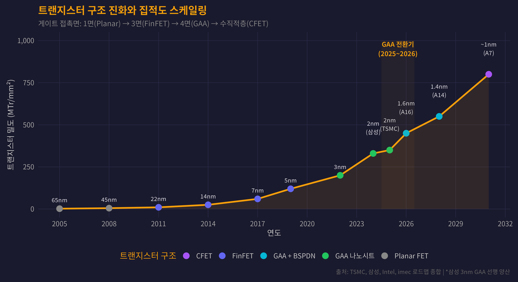

**핵심 전환점: 2025~2026**

2025~2026년은 TSMC, 삼성, Intel **3사 모두** GAA 기반 2nm 공정을 양산 개시하는 역사적 전환기다. 삼성이 2022년 3nm에서 GAA를 선행 적용했지만, 수율 문제로 시장 영향은 제한적이었다. 2025년 TSMC N2의 양산 개시와 함께 GAA가 본격적인 주류 기술로 자리잡았다.

# 2 FinFET의 한계와 GAA의 등장

## 2.1 FinFET: 12년간의 혁신

FinFET(Fin Field-Effect Transistor)은 2011년 Intel이 22nm에서 처음 양산한 **3차원 트랜지스터** 구조다. 기판 위로 돌출된 “지느러미(Fin)” 형태의 채널을 게이트가 3면에서 감싸 전류 흐름을 제어한다. 이는 기존 Planar FET의 1면 접촉 대비 **누설전류를 50% 이상 줄이고**, 동일 면적에서 더 높은 전류를 흘릴 수 있게 했다.

## 2.2 FinFET의 물리적 한계

그러나 3nm 이하에서 FinFET은 근본적인 한계에 부딪혔다:

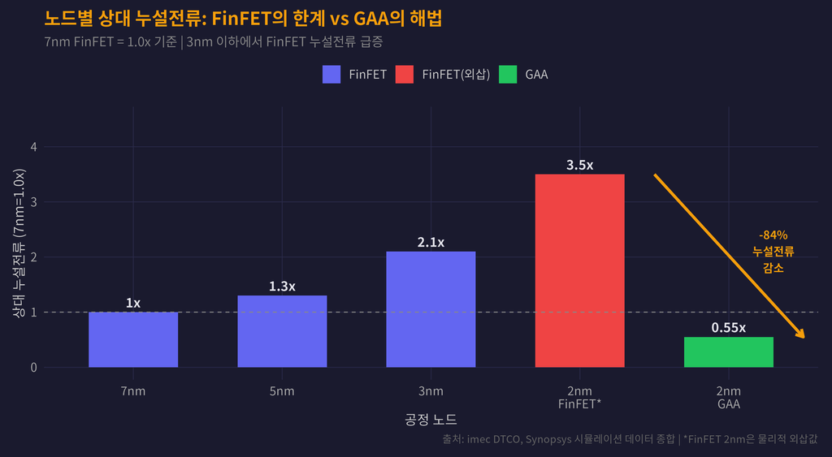

Figure 2: FinFET vs GAA: 누설전류 및 게이트 제어력 비교

**FinFET의 3가지 핵심 한계:**

1. **핀 바닥 누설(Sub-fin Leakage)**: 게이트가 핀의 3면만 감싸므로, 바닥면에서 전류가 새어나간다. 3nm 이하에서 이 누설이 총 소비전력의 30% 이상을 차지.
2. **핀 폭 조절의 한계**: 성능을 높이려면 핀 수를 늘려야 하지만, 이는 면적 증가로 직결. 핀 폭 자체를 줄이면 양자 효과(Quantum Confinement)로 이동도가 급감.
3. **전력 밀도 포화**: 핀 피치 축소 시 열 밀도가 급격히 증가하여 열설계 마진이 부족.

## 2.3 GAA 나노시트: 게이트가 4면을 감싸다

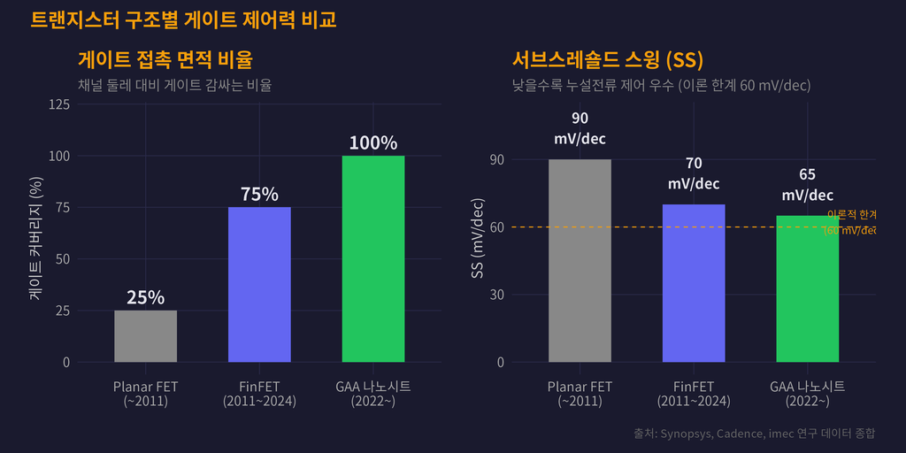

Figure 3: 게이트 접촉면 진화: Planar(1면) → FinFET(3면) → GAA(4면)

GAA(Gate-All-Around) 나노시트 트랜지스터는 **수평으로 적층된 나노시트(nanosheet)** 형태의 채널을 게이트 물질이 완전히 감싸는 구조다. 핵심 장점은 다음과 같다:

- **완전한 정전기 제어**: 게이트가 채널 4면을 모두 감싸 DIBL(Drain-Induced Barrier Lowering)을 근본적으로 억제
- **나노시트 폭 가변성**: 채널 폭을 8~40nm 범위에서 자유롭게 조절해 성능/전력 트레이드오프 최적화
- **누설전류 73.6% 감소**: 6T-SRAM 기준, 동일 조건에서 FinFET 대비 대폭 개선
- **서브스레숄드 스윙 65 mV/dec**: 이론 한계(60 mV/dec)에 근접한 스위칭 효율

# 3 파운드리 3사 경쟁: 2nm 전쟁

## 3.1 TSMC N2: 안정적 수율의 왕자

TSMC는 2025년 4분기에 **N2(2nm)** 양산을 개시했다. 이는 TSMC 최초의 GAA 나노시트 공정이다.

**핵심 성능:**

- 동일 전력에서 성능 **15% 향상** (vs N3E)
- 동일 성능에서 전력 **25~30% 절감**
- 양산 초기 수율: **65~70%** (업계 최고 수준)
- SHPMIM 커패시터 도입으로 전력 안정성 2배 향상

**파생 공정 로드맵:**

- **N2P** (2026H2): 성능 강화 파생, 추가 전력/성능 개선
- **A16** (2026H2): Super Power Rail(SPR) 후면 전력 전달 통합, AI/HPC 특화

## 3.2 삼성 SF2/SF2P: 추격자의 반격

삼성은 2022년 3nm에서 GAA를 **세계 최초 양산**한 선행 경험을 보유하고 있다.

**SF2 (2nm, 2025H2):**

- 3nm GAA 대비 성능 **5%↑**, 전력효율 **8%↑**, 면적 **5%↓**
- 2025년 11월 기준 수율 55~60%
- Exynos 2600 양산에 적용

**SF2P (2nm 성능강화, 2026):**

- SF2 대비 클럭 **12%↑**, 전력효율 **25%↑**, 면적 **8%↓**
- 수율 **70%** 달성 (양산 기준 충족)
- Qualcomm, AMD의 2nm 물량 확보 협상 진행

## 3.3 Intel 18A: RibbonFET + PowerVia 동시 도입

Intel은 18A에서 **RibbonFET(GAA)** 과 **PowerVia(후면 전력 전달)** 를 동시에 도입하는 가장 공격적인 전략을 택했다.

- 전력당 성능(Perf/W) **15% 향상**
- 트랜지스터 밀도 **30% 증가** (vs Intel 3)
- 2025H2 양산 개시, Panther Lake·Clearwater Forest 첫 제품 출하
- Microsoft 18A 수주 확보, Google 협상 중

Table 2: 파운드리 3사 2nm 공정 비교 (2026년 5월 기준)

[output not shown]

## 3.4 파운드리 수율 경쟁 추이

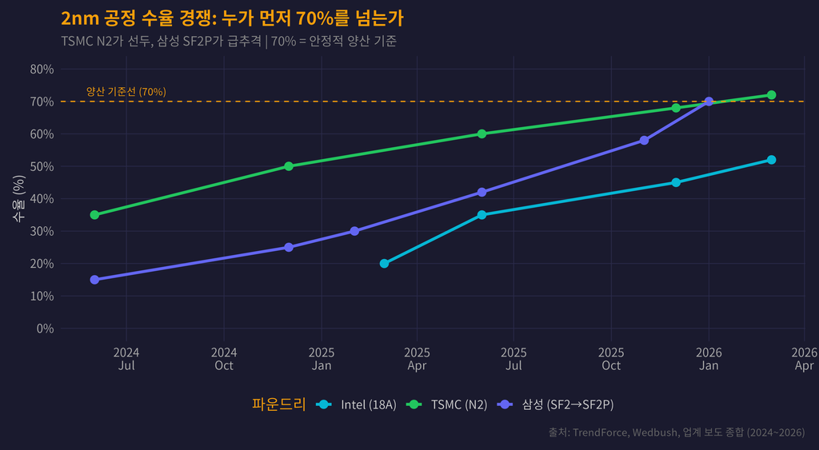

Figure 4: 파운드리 3사 2nm 수율 경쟁 추이 (2024~2026)

# 4 핵심 기술 심층 분석

## 4.1 GAA 나노시트 구조 원리

GAA 나노시트 트랜지스터의 핵심은 **수평으로 적층된 실리콘 나노시트**를 게이트 물질(High-K/Metal Gate)이 완전히 둘러싸는 것이다.

**제조 공정 핵심 단계:**

1. **Si/SiGe 초격자 증착**: 기판 위에 실리콘과 실리콘-게르마늄 층을 교대로 쌓는다 (3~4 쌍)
2. **핀 패터닝**: EUV 리소그래피로 핀 구조를 형성
3. **SiGe 선택적 에칭**: SiGe 희생층만 제거하여 Si 나노시트를 분리 (Channel Release)
4. **게이트 스택 증착**: High-K 유전체 + Metal Gate를 나노시트 주위에 ALD로 원자 단위 증착
5. **소스/드레인 형성**: 에피택셜 성장으로 접촉 저항 최소화

**공정 난이도의 핵심: Channel Release**

SiGe 선택적 에칭(Channel Release)은 GAA 공정의 가장 까다로운 단계다. Si 나노시트를 손상시키지 않으면서 SiGe만 정밀하게 제거해야 한다. 이 공정의 정밀도가 수율을 결정하며, **ALD(원자층증착)**, **ALE(원자층에칭)** 기술이 핵심이다. HPSP의 High Pressure Anneal 기술이 이 단계에서 게이트 유전체의 결함을 줄이는 데 사용된다.

## 4.2 나노시트 폭 가변성의 전략적 가치

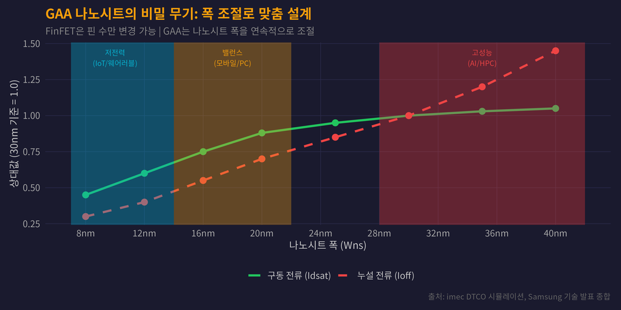

Figure 5: 나노시트 폭 조절에 따른 성능/전력 트레이드오프

GAA 나노시트의 가장 큰 장점 중 하나는 **나노시트 폭(Wns)**을 연속적으로 조절할 수 있다는 점이다. 같은 공정에서 폭만 바꾸면:

- **좁은 나노시트 (8~14nm)**: IoT·웨어러블용 초저전력 칩
- **중간 나노시트 (16~24nm)**: 모바일 AP·PC CPU
- **넓은 나노시트 (30~40nm)**: AI 가속기·HPC용 고성능 칩

이는 FinFET에서 핀 수(정수 단위)로만 성능을 조절하던 것보다 훨씬 세밀한 최적화를 가능하게 한다.

## 4.3 후면 전력 전달 (BSPDN)

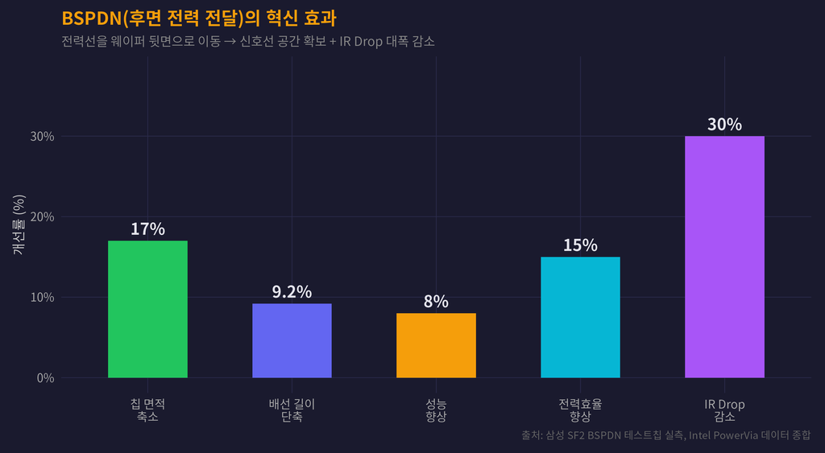

Figure 6: 후면 전력 전달(BSPDN) 도입에 따른 성능 개선 효과

**BSPDN(Backside Power Delivery Network)**은 전력 배선을 웨이퍼 뒷면으로 이동시키는 혁신 기술이다:

- **기존**: 전력선과 신호선이 웨이퍼 앞면에 공존 → 공간 경쟁, 간섭 발생
- **BSPDN**: 전력선을 뒷면에 배치 → 앞면은 신호선 전용 → 배선 밀도 + 신호 품질 동시 개선

**도입 일정:**

- Intel: **18A부터** PowerVia 동시 도입 (업계 최초 양산 적용)
- TSMC: **A16(1.6nm)**부터 Super Power Rail(SPR) 도입 (2026H2)
- 삼성: **SF2 + BSPDN** 2027년 양산 적용 예정

# 5 차세대 기술: CFET과 그 너머

## 5.1 CFET (Complementary FET): 수직 적층의 미래

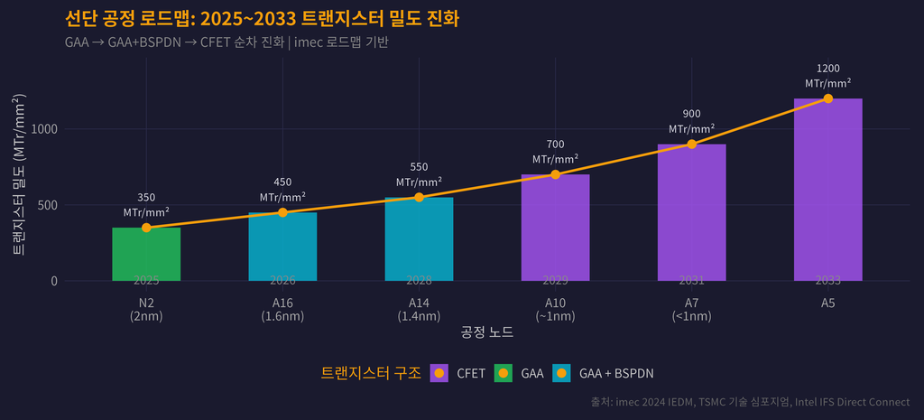

Figure 7: GAA에서 CFET으로: 차세대 트랜지스터 로드맵

CFET(Complementary FET)은 GAA 이후의 차세대 구조로, **nMOS와 pMOS를 수직으로 적층**한다:

- **기존**: nMOS와 pMOS가 좌우로 나란히 배치 → 면적 낭비
- **CFET**: nMOS 위에 pMOS를 올려놓음 → 셀 높이를 **30~50% 축소**

imec은 **A7 노드(~1nm, 2031년)**에서 CFET 상용화를 예측하며, 모놀리식(mCFET)과 순차 적층(sCFET) 두 가지 접근법을 연구 중이다.

# 6 EUV 리소그래피의 진화

## 6.1 High-NA EUV: 서브 2nm의 열쇠

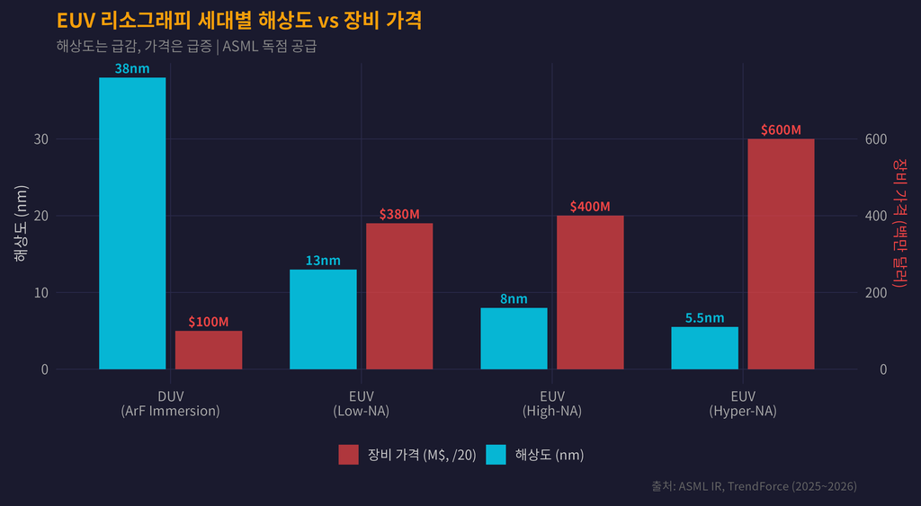

Figure 8: EUV 리소그래피 진화: NA 0.33 → 0.55 → Hyper-NA

ASML의 **High-NA EUV (EXE:5000/5200 시리즈)**는 서브 2nm 공정의 핵심 인프라다:

- **NA 0.55**로 해상도 8nm 달성 (기존 Low-NA의 13nm 대비 **38% 향상**)
- **Twinscan EXE:5200B**: 시간당 175매 처리, 오버레이 정밀도 0.7nm
- Intel이 업계 최초로 EXE:5200B 수령 및 검수 완료 (2025년 12월)
- 삼성: 2025년말 첫 번째, 2026H1 두 번째 장비 수령
- **양산 본격 적용**: 2027~2028년 (ASML CEO 전망)

# 7 시장 규모와 성장 전망

## 7.1 글로벌 파운드리 시장 성장

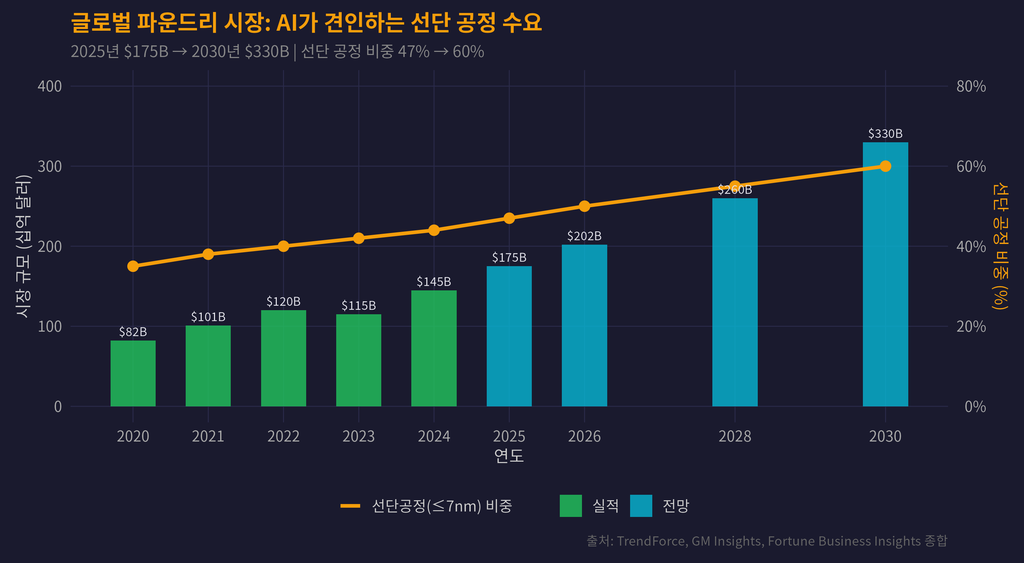

Figure 9: 글로벌 반도체 파운드리 시장 규모 및 전망

## 7.2 선단 공정별 시장 점유율

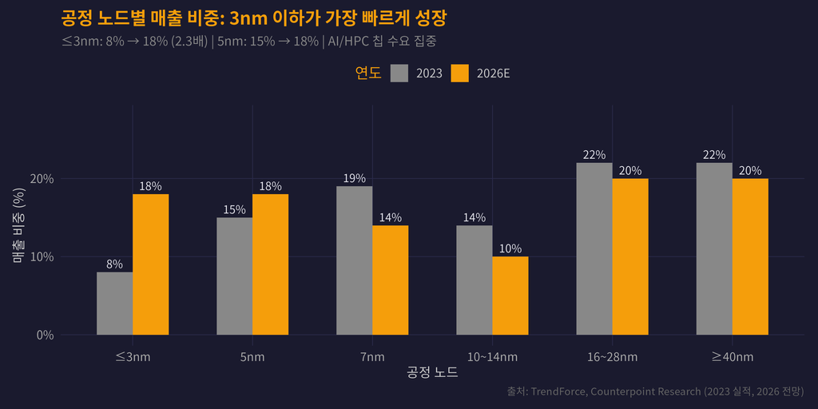

Figure 10: 공정 노드별 파운드리 매출 비중 변화 (2023 vs 2026E)

# 8 투자 시사점

## 8.1 수혜 밸류체인 분석

**투자 핵심 포인트**

GAA 전환은 **반도체 장비·소재·검사** 밸류체인 전체를 업그레이드한다. FinFET→GAA 전환 시 공정 단계가 20% 이상 증가하며, 웨이퍼당 장비 사용량이 비례 증가한다. 이는 곧 장비·소재 기업의 매출 확대로 직결된다.

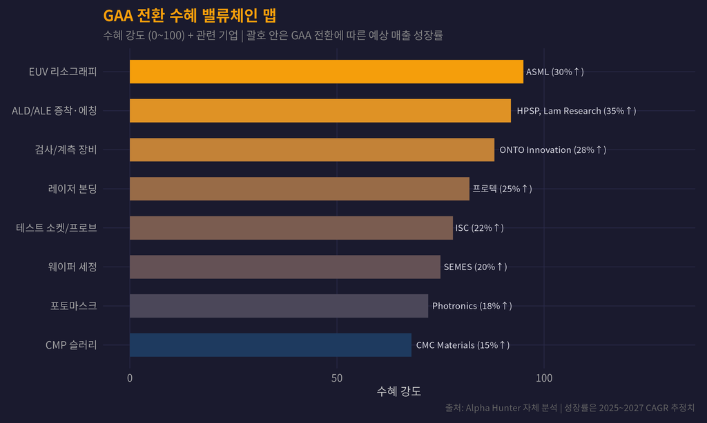

Figure 11: GAA 전환에 따른 밸류체인별 수혜 강도

## 8.2 Alpha Hunter 관련 종목 매핑

Table 3: 선단 공정 기술 관련 Alpha Hunter 히든젬 종목

[output not shown]

## 8.3 핵심 투자 포인트 정리

**리스크 요인**

1. **수율 리스크**: GAA 전환 초기 수율 문제로 양산 지연 가능성 (특히 삼성, Intel)
2. **비용 급증**: 2nm 웨이퍼 가격 $20,000+ 추정 (5nm 대비 2배). 장비 비용도 급증
3. **수요 집중**: 선단 공정 수요가 Apple·NVIDIA·AMD 등 소수 고객에 집중 → 고객사 투자 사이클에 종속
4. **중국 규제**: 미국의 대중 반도체 장비 수출 규제 강화 시, 장비 업체의 중국 매출 타격

**면책 조항**

이 프로젝트는 가상 투자 시뮬레이션 목적으로 작성되었습니다. 실제 투자 권유가 아닙니다.

*Alpha Hunter × Chimera AI — 기술이 투자를 이끈다*